# PartialFKR User Manual

# PartialFKR User Manual

**Version 0.1 · ideocentric**

1. Introduction
2. Getting Started
3. Loading and Saving
4. The Partial Canvas
5. Playback
6. Selection
7. Editing
8. Reduction Filters
9. Gap Operations
10. The Inspector
11. Export
12. Keyboard Shortcuts

## 1. Introduction

### 1.1 What is PartialFKR?

PartialFKR is an interactive sinusoidal analysis, editing, and resynthesis application. It analyzes audio files and represents the sound as a set of **partials** — individual frequency tracks that each carry a time-varying frequency and amplitude envelope. You can listen to the resynthesized audio, selectively mute or delete partials, and export the result to drive other instruments and synthesis environments.

PartialFKR is a spiritual successor to Michael Klingbeil’s SPEAR. Its analysis engine is based on Loris, an open-source library for sound morphing and transformation.

### 1.2 The re-orchestration workflow

The core workflow is **qualitative partial reduction**:

1. Load an audio file and analyze it.
2. Listen to the resynthesized result — it should closely match the original.
3. Mute or delete partials until the source is no longer recognizable.
4. Export the reduced partial set to drive other instruments.

The aesthetic goal is *re-orchestration*: hearing an implied source signal — its onsets, phonetic gestures, melodic shape — refracted through the timbre of an unrelated instrumental ensemble. Fidelity is not the goal; characteristic preservation through aggressive reduction is.

### 1.3 Supported platforms

- **macOS** (Apple Silicon and Intel)
- **Windows** (x64 and ARM64)
- **Linux** (x86_64 and ARM64)

## 2. Getting Started

### 2.1 Installation

**macOS**: Open the `.dmg`, drag PartialFKR to your Applications folder.  
**Windows**: Run the NSIS installer (`.exe`) and follow the prompts.  
**Linux**: Install the `.deb` (Debian/Ubuntu) or `.rpm` (Fedora/RHEL) package for your architecture.

### 2.2 First launch

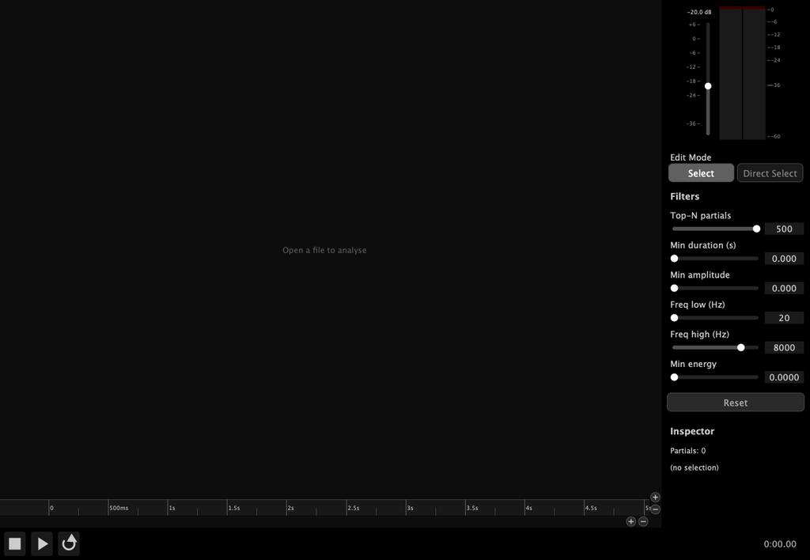

S-01 — Empty application window on first launch

### 2.3 Interface overview

After loading a project or completing an analysis, the interface is divided into three main areas:

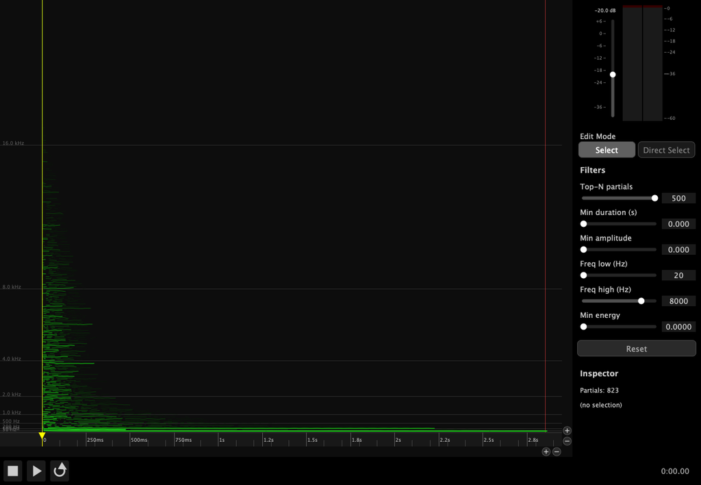

S-02 — Application window with a project loaded

[output not shown]

The following annotated images label each area and control (see the legend below):

[figure not shown]

S-03c — Tools tab, transport bar, and canvas markers detail (items 1–26)

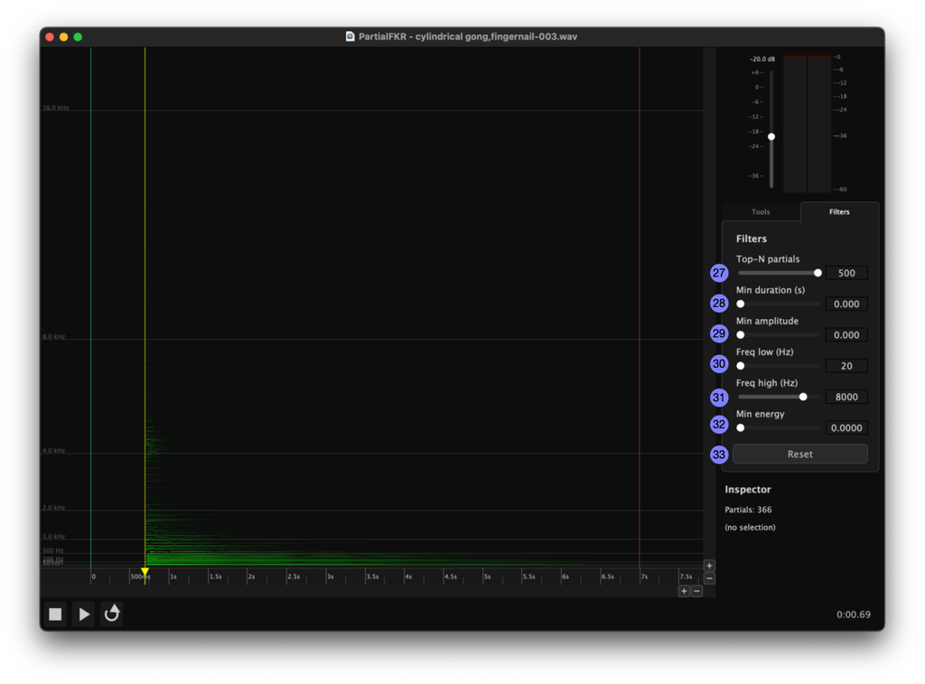

S-03d — Filters tab detail (items 27–33)

**Interface legend:**

[output not shown]

## 3. Loading and Saving

### 3.1 Analyzing an audio file

**File → Analyze Audio…** opens a file picker. You can also click the **“Open a file to analyse”** link displayed in the center of an empty canvas. Select a WAV or AIFF file. PartialFKR will analyze it using sinusoidal modeling and populate the canvas with the resulting partials. Analysis time depends on file length; a progress indicator is shown during analysis.

Once analysis is complete, the window title updates to show the source filename and the proxy icon is set to the audio file.

> **Note:** A project can only hold one analyzed audio file. Once analysis is complete, the Analyze Audio menu item is disabled for that window. Open a new window (⌘N) to analyze a second file.

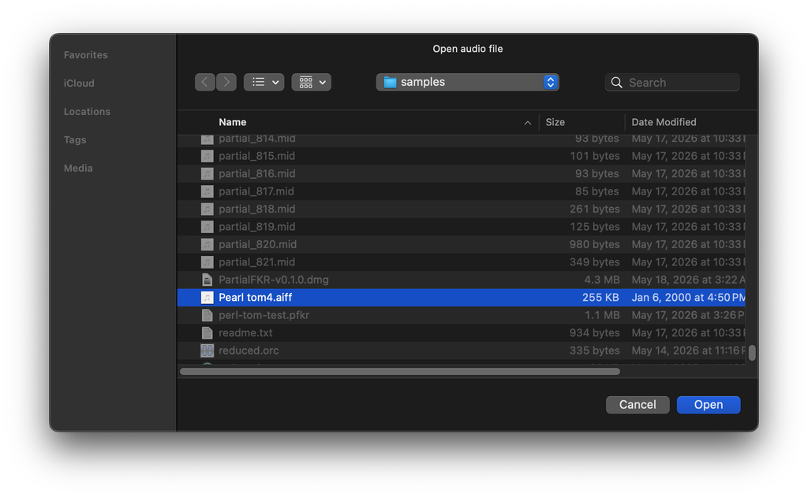

S-07 — Analyze Audio file picker

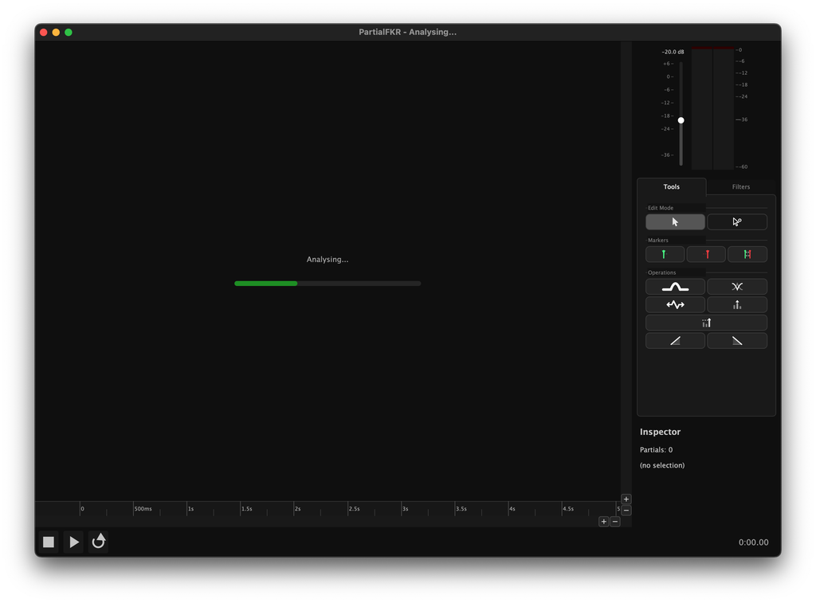

S-03a — Analysis in progress

### 3.2 Opening a project (.pfkr)

**File → Open…** (⌘O) opens a `.pfkr` project file. A `.pfkr` file stores the complete partial set, reduction filter settings, zoom state, and other view parameters. It does not store the original audio.

On macOS, you can also double-click a `.pfkr` file in Finder, or drag it onto the PartialFKR dock icon.

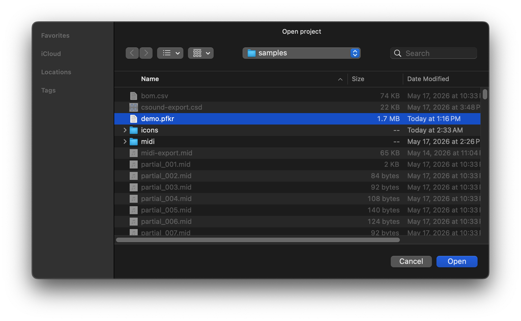

S-08 — Open Project file picker

**Opening into a specific window:** If the frontmost window has no partials loaded, the file is opened into that window. If the window already has content, a new window is created.

### 3.3 Opening from Finder

After the application has been run at least once, `.pfkr` files will show “Open with PartialFKR” in Finder’s context menu. Double-clicking a `.pfkr` file opens it directly in PartialFKR.

### 3.4 Save and Save As

| Command | Key | Behavior |
| --- | --- | --- |
| Save | ⌘S | Saves to the current `.pfkr` file. If the project has never been saved, falls through to Save As. |
| Save As… | ⌘⇧S | Prompts for a new filename and saves. |

After a successful save, the window title updates to the project filename and the macOS proxy icon points to the `.pfkr` file.

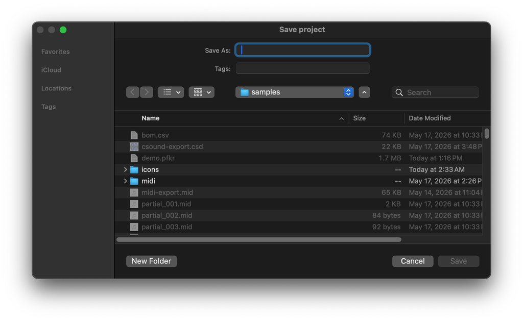

S-09 — Save As dialog

### 3.5 Unsaved changes

If you close a window or quit the application with unsaved changes, a dialog appears:

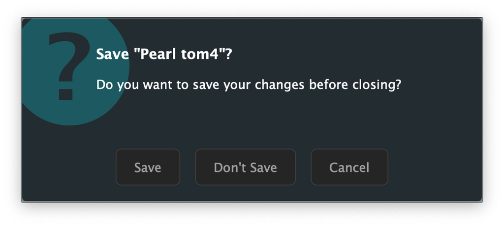

S-10 — Unsaved changes dialog

- **Save** — saves the project, then closes.
- **Don’t Save** — discards changes and closes.
- **Cancel** — returns to the application without closing.

When quitting with multiple dirty windows open, each window is handled in sequence. Cancelling any one of them aborts the quit.

## 4. The Partial Canvas

### 4.1 Reading the display

The canvas plots partials as colored lines:

- **Horizontal axis**: Time (seconds)
- **Vertical axis**: Frequency (Hz), with lower frequencies at the bottom
- **Color**: All partials are drawn in green
- **Brightness and line weight**: Both increase with amplitude — louder partials appear brighter and thicker

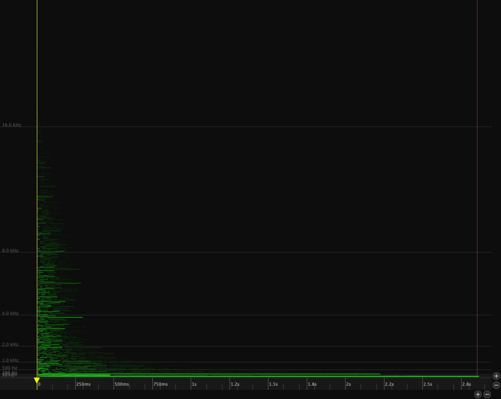

S-11 — Canvas with default zoom showing all partials

### 4.2 Navigating: zoom and pan

**Zoom**

All scroll-based zoom is anchored at the cursor position.

| Action | Effect |
| --- | --- |
| Scroll / wheel | Zoom frequency axis (vertical) |
| ⌘+scroll or ⌥+scroll | Zoom time axis (horizontal) |
| Pinch (trackpad) | Zoom both axes together |
| ⌘= | Zoom in (time axis) |
| ⌘− | Zoom out (time axis) |
| ⌘0 | Zoom to fit — shows all partials |

The zoom buttons in the canvas chrome perform the same operations: the pair in the bottom-right zoom the time axis, the pair on the right zoom the frequency axis.

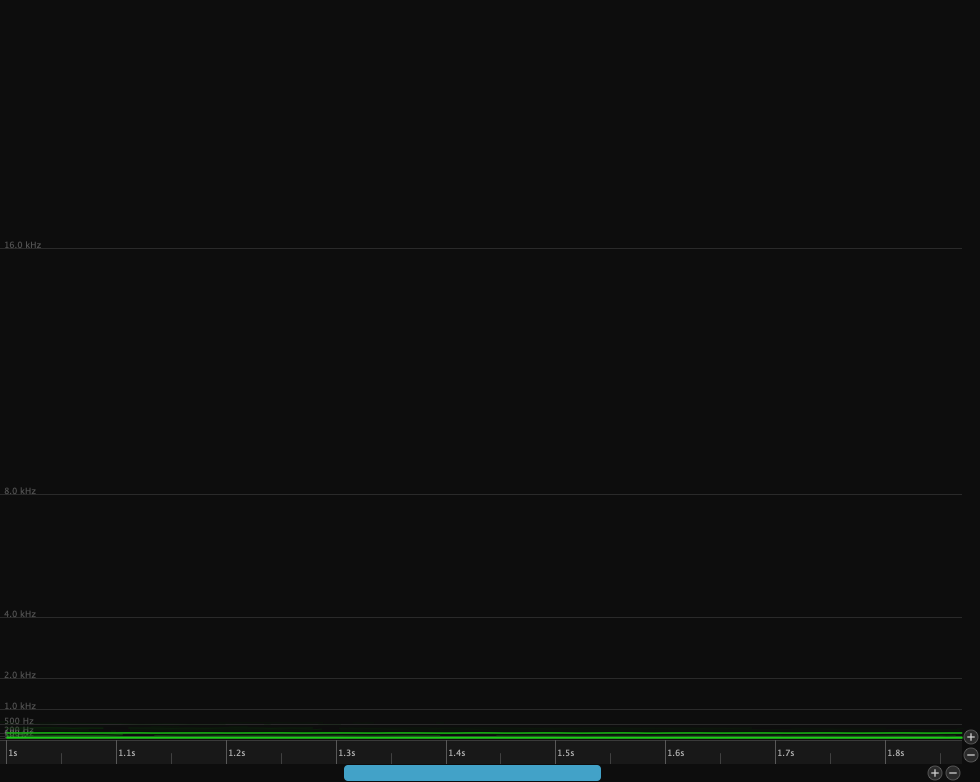

S-12 — Canvas zoomed in, showing individual partial detail

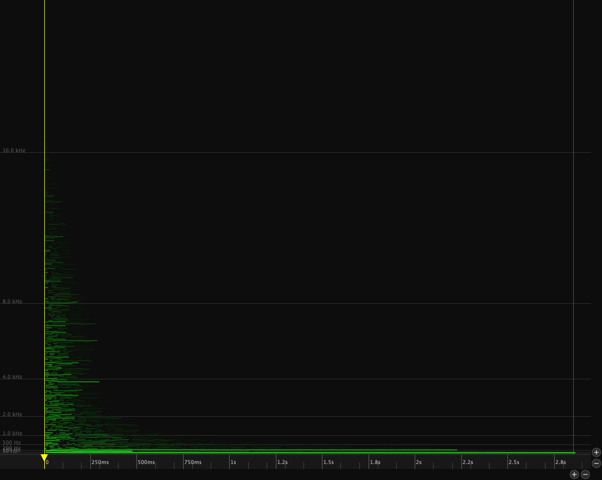

S-13 — Canvas zoomed to fit, showing all partials

**Pan**

| Action | Effect |
| --- | --- |
| ⇧+scroll | Pan time (horizontal) |
| Arrow keys | Pan time (← →) or frequency (↑ ↓) |
| Page Up / Down | Pan frequency up / down by one page |
| Home / End (or ⌘← / ⌘→) | Jump playback to file start / end (view follows) |
| Drag empty canvas area | Pan time and frequency |

### 4.3 The playhead

The yellow vertical line indicates the current playback position. Click anywhere on the ruler (the time strip at the bottom of the canvas, item 6) to reposition the playhead. Dragging the playhead handle (item 8) scrubs audio.

## 5. Playback

### 5.1 Play, Pause, Stop

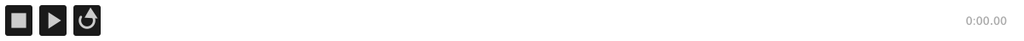

S-16 — Transport bar in stopped state

| Button | Key | Action |
| --- | --- | --- |
| ▶ Play (item 2) | Space | Start playback from the current playhead position |
| ⏸ Pause (item 2) | Space | Pause playback (retains position) |
| ⏹ Stop (item 1) | — | Stop playback and return to the in-point |

Playback can also be started by pressing **Space** anywhere in the canvas.

**Go to Start / End** — jump the playhead to either end of the file. The view scrolls to follow.

| Menu | Key | Action |
| --- | --- | --- |
| Transport → Go to Start | ⌘← (or Home) | Move the playhead to the beginning of the file |
| Transport → Go to End | ⌘→ (or End) | Move the playhead to the end of the file |

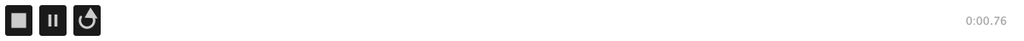

S-17 — Transport bar in playing state

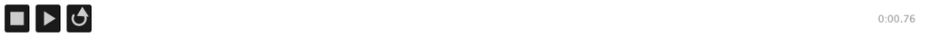

S-18 — Transport bar in paused state

### 5.2 Loop mode

Click the **Loop** button (item 3) or use **Transport → Loop** to enable looped playback. When loop is on, playback restarts at the beginning automatically.

[figure not shown]

S-19 — Transport bar with loop enabled

### 5.3 Scrubbing

Hold **Option (⌥)** and drag the playhead handle (item 8) to scrub through the audio. The canvas and synth follow the drag position in real time. When you release, playback resumes from the scrub position.

### 5.4 In and Out markers

The **In marker** (item 7) and **Out marker** (item 9) define the active play region on the canvas ruler. Drag them to set the range; playback starts from the In point and stops (or loops) at the Out point. Use **Stop** to return to the In point.

You can also set the markers from the keyboard, the Transport menu, or the marker buttons in the Tools tab (items 16–18):

| Action | Shortcut | Menu | Button |
| --- | --- | --- | --- |
| Set In Point to playhead | ⌥I | Transport → Set In Point | Item 16 |
| Set Out Point to playhead | ⌥O | Transport → Set Out Point | Item 17 |
| Set In/Out to span selection | ⌥S | Transport → Set In/Out from Selection | Item 18 |

**Set In/Out from Selection** (item 18) is enabled only when one or more partials are selected; it sets the In marker to the earliest breakpoint and the Out marker to the latest breakpoint across the selection.

### 5.5 Output gain and level meter

The **output gain fader** (item 10) and **stereo level meter** (item 11) are at the top of the right panel, above the tab bar. The fader controls master output gain (−40 to +6 dB, default −20 dB). The meter shows peak output with hold indicators and clip lights.

Click the clip lights to reset them after a peak-clipping event.

### 5.6 Selection-based solo

When partials are selected, only the selected partials are audible during playback. This makes it easy to isolate specific partials and assess their contribution. Deselect all partials to hear the full (unfiltered) resynthesis.

## 6. Selection

PartialFKR has two selection modes, chosen with keyboard shortcuts or the **Edit Mode** buttons (items 14–15) in the **Tools tab** of the right panel.

### 6.1 Select mode (V key)

Select mode operates on **whole partials**.

| Action | Result |
| --- | --- |
| Click a partial | Select it (deselects others) |
| ⌘+click | Add/remove from current selection |
| Drag from empty area | Rubber-band: select all partials whose time range intersects the rectangle |
| ⌘+drag | Add/remove from selection by rectangle |
| Click empty area | Deselect all |

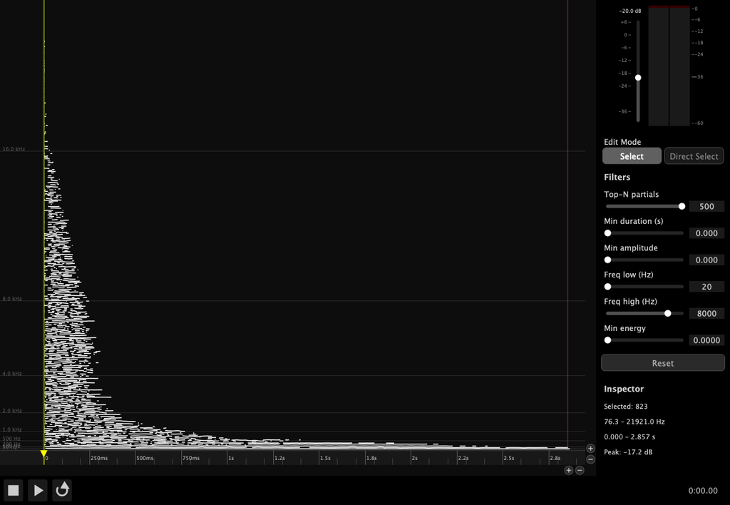

### 6.2 Direct Select mode (A key)

Direct Select mode operates on **individual breakpoints** — the control points that define a partial’s trajectory.

| Action | Result |
| --- | --- |
| Click a breakpoint | Select it |
| ⌘+click | Add/remove a breakpoint from selection |
| Drag from empty area | Rubber-band: select all breakpoints in the rectangle |
| Drag a selected breakpoint | Move it to a new time/frequency position |

Breakpoints are displayed as small dots on each partial when Direct Select mode is active. Selected breakpoints are highlighted.

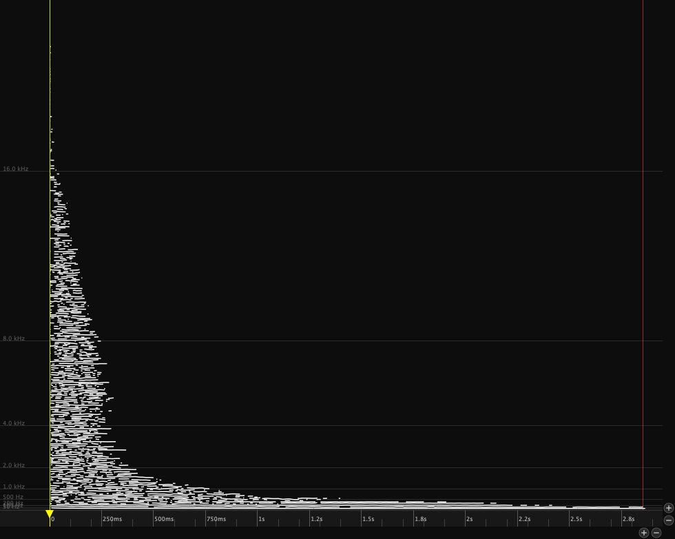

S-25 — Canvas showing partials selected

### 6.3 Select All, Deselect All, Invert Selection

These commands operate in the current mode (whole partials or breakpoints):

| Command | Key |
| --- | --- |
| Select All | ⌘A |
| Deselect All | ⌘⇧A |
| Invert Selection | ⌘⇧I |

## 7. Editing

All editing operations are undoable. Use ⌘Z to undo and ⌘⇧Z to redo.

### 7.1 Copy, Cut, Paste

| Command | Key | Notes |
| --- | --- | --- |
| Copy | ⌘C | Copies selected partials (with full breakpoint data and color) to the clipboard |
| Cut | ⌘X | Copies then deletes |
| Paste | ⌘V | Pastes at the position last clicked in the canvas background |

**Cross-window paste**: The clipboard is shared across all open windows. Copy in one window and paste into another. To set the paste position in the destination window, click the canvas background before pasting.

### 7.2 Delete

Press **Delete** or **Backspace** to delete: - In Select mode: removes the selected partials entirely - In Direct Select mode: removes the selected breakpoints from their partials

Deletion is undoable.

### 7.3 Undo and Redo

PartialFKR maintains a full undo history for all structural edits (delete, paste, stretch, normalize, bridge, crossfade, fade). Use ⌘Z / ⌘⇧Z, or the Edit menu.

The Edit menu shows a description of the next undo/redo operation (e.g., “Undo Delete”).

### 7.4 Stretch / Compress

Press **T**, click the **Stretch** button (item 21), or use **Edit → Stretch / Compress…** to time-scale the selected partials or breakpoints.

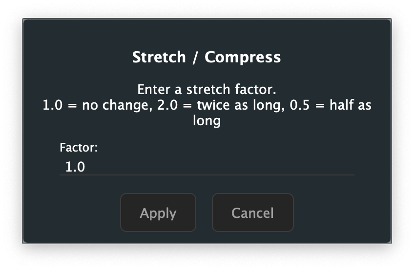

S-30 — Stretch / Compress dialog

Enter a factor: - **1.0** — no change - **2.0** — twice as long (slowed down) - **0.5** — half as long (sped up)

The operation anchors to the earliest start time in the selection. Stretch is undoable.

### 7.5 Normalize

Click the **Normalize** button (item 23) or use **Edit → Normalize** to scale all unmuted partials so the loudest peak in the resynthesized output reaches 0 dBFS. This is useful after heavy reduction, when the remaining partials may be much quieter than the original.

Normalize is undoable and runs asynchronously — a brief pause may occur on large partial sets.

### 7.6 Scale Amplitude

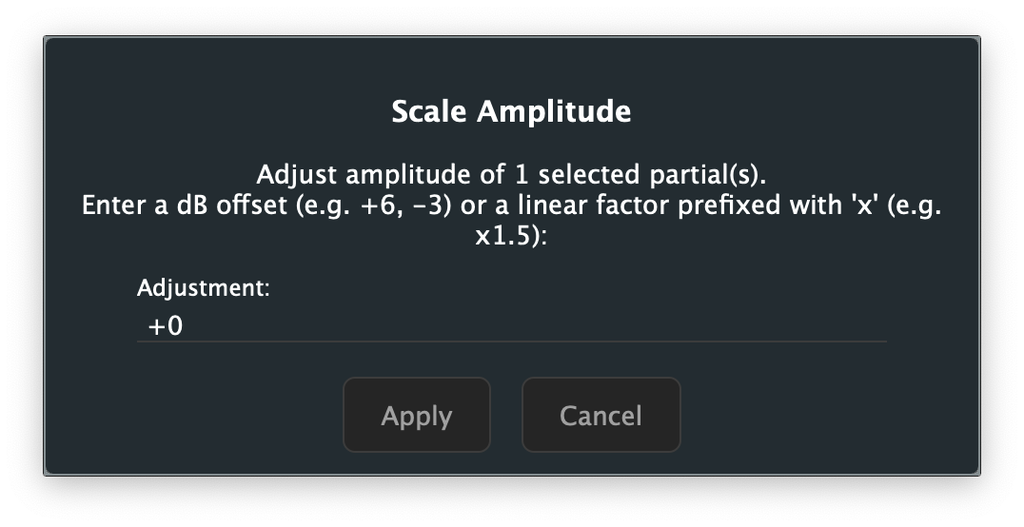

S-31 — Scale Amplitude dialog

Enter the adjustment as a dB offset (e.g. `+6`, `−3`) or as a linear multiplier prefixed with `x` (e.g. `x1.5`). Scale Amplitude is undoable.

### 7.7 Fade In / Fade Out

The **Fade In** (item 24) and **Fade Out** (item 25) buttons apply an amplitude envelope to the selected partials, ramping from silence over the region between the **In marker** and **Out marker**.

- **Fade In** — amplitude ramps from 0 at the In marker to full amplitude at the Out marker
- **Fade Out** — amplitude ramps from full amplitude at the In marker to 0 at the Out marker

> **Note:** Both buttons are enabled only when a valid In/Out range is set (Out marker is after In marker) and partials are selected. Set your In and Out markers before applying a fade.

Both operations insert breakpoints at the In and Out marker positions and scale amplitudes across the range. They are undoable.

## 8. Reduction Filters

The **Filters tab** of the right panel contains six sliders (items 27–32) that instantly hide partials meeting threshold criteria. Filtered partials are muted in real time; you can hear the effect immediately during playback.

Filtering is non-destructive: partials are hidden, not deleted. Use the **Reset** button (item 33) to restore all partials.

### 8.1 Workflow

The typical reduction workflow:

1. Play the full resynthesis to establish a reference.
2. Switch to the Filters tab (item 13).
3. Adjust a filter slider (e.g., Top-N) while playing to hear the effect in real time.
4. When satisfied with a setting, move to the next filter.
5. Export when the desired reduction level is reached.

### 8.2 Top-N partials (item 27)

Retains only the **N loudest partials** (by peak amplitude). All other partials are muted.

- Range: 1–500
- Default: 500 (effectively no filtering)
- Use this as the primary broadness control — start by setting it low (e.g., 10–30) and work up until you have the desired density.

### 8.3 Minimum duration (item 28)

Hides partials shorter than the threshold duration.

- Range: 0–250 ms
- Default: 0 (no filtering)
- Useful for removing very short transient artifacts from the analysis.

### 8.4 Minimum amplitude (item 29)

Hides partials whose **peak amplitude** falls below the linear threshold.

- Range: 0.0–1.0 (linear)
- Default: 0.0 (no filtering)

### 8.5 Frequency band — low / high (items 30–31)

- **Freq low** (item 30): hides partials whose frequency is below the threshold (removes bass content)
- **Freq high** (item 31): hides partials whose frequency is above the threshold (removes treble content)
- Range: 20–20,000 Hz (logarithmic scale)
- Defaults: 20 Hz (low), 8000 Hz (high)

Use these together to isolate a specific frequency range. For example, set Freq low to 200 Hz and Freq high to 4000 Hz to hear only midrange partials.

### 8.6 Minimum energy (item 32)

Hides partials with very little total energy (amplitude × duration).

- Range: 0.0–0.1
- Default: 0.0 (no filtering)
- Energy is computed as ∑(average amplitude × Δt) in linear·seconds.
- This filter is more musically useful than Min Amplitude for removing low-level sustained partials.

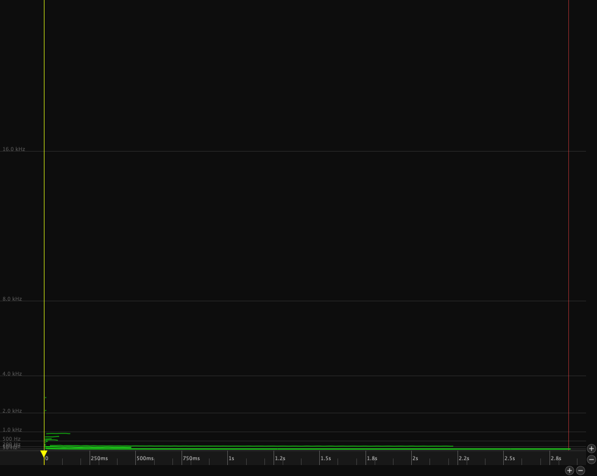

S-37 — Canvas showing filtered result (fewer partials visible)

### 8.7 Reset (item 33)

The **Reset** button clears all six filter sliders to their defaults, restoring all muted partials to audibility.

## 9. Gap Operations

Gap operations combine two separate partial fragments into a single continuous partial. Both operations are undoable.

### 9.1 Bridge Partials — ⌘J (item 19)

Bridges the **gap** between two partial fragments that should be continuous but were separated because the amplitude dropped below the analysis threshold.

**Triggering in Select mode**: Select exactly two partials where one ends before the other begins (a gap exists between them). Press ⌘J or click the Bridge button (item 19).

**Triggering in Direct Select mode**: Select one breakpoint from each of two different partials. Press ⌘J.

**What it does**: Linearly interpolates frequency and amplitude at 5 ms intervals across the gap, producing a smooth connection between the two fragments. The two originals are replaced by a single merged partial.

> **Tip:** If ⌘J is greyed out, check that exactly two partials are selected, that they do not overlap in time, and that one ends before the other begins.

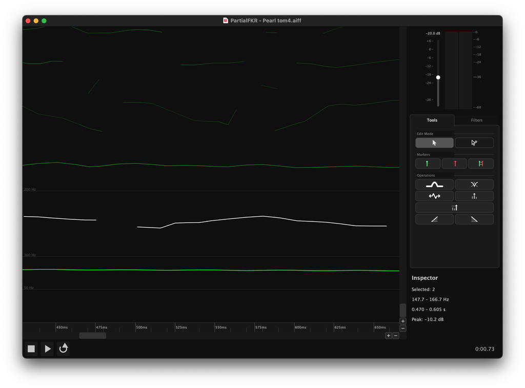

S-38 — Two partials with a gap (before Bridge)

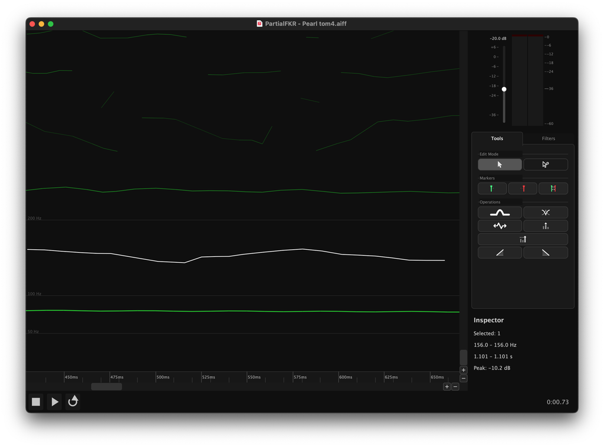

S-39 — Single partial after Bridge Partials

### 9.2 Crossfade Overlap — ⌘⇧J (item 20)

Blends two overlapping partials into a single continuous partial by **crossfading** the overlap region.

**Triggering**: Same as Bridge Partials, but the two selected partials must overlap in time (the first has not ended when the second begins). Press ⌘⇧J or click the Crossfade button (item 20).

**What it does**: In the overlap region, amplitude is weighted so that the first partial fades out while the second fades in. Frequency is interpolated throughout. The result is a single merged partial with no abrupt transitions.

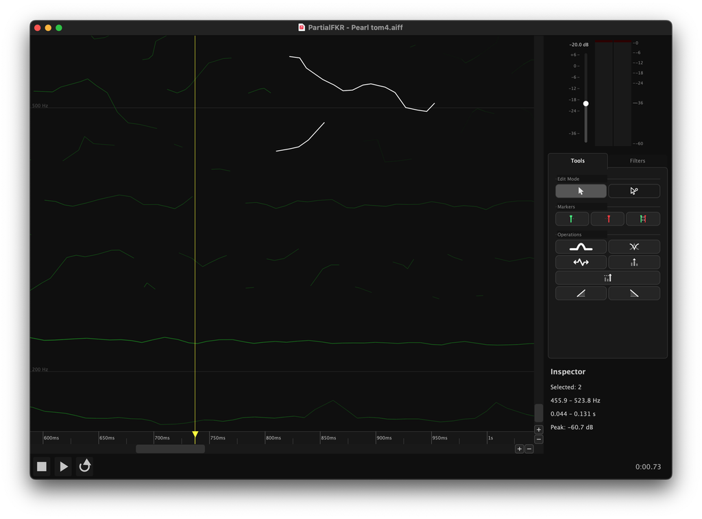

S-40 — Two overlapping partials (before Crossfade)

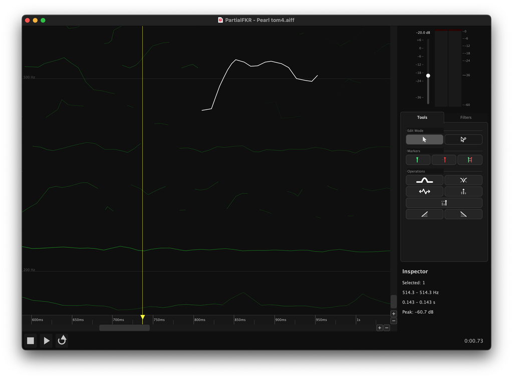

S-41 — Single partial after Crossfade Overlap

## 10. The Inspector

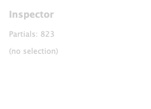

S-42 — Inspector with no selection

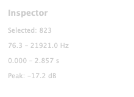

S-43 — Inspector with partials selected

| Field | Description |
| --- | --- |
| **Partials** | Number of selected partials (or total if nothing is selected) |
| **Frequency range** | Lowest and highest fundamental frequency across the selection |
| **Duration** | Time span from earliest onset to latest offset |
| **Peak amplitude** | Maximum amplitude value across the selection |

The Inspector updates immediately as the selection changes.

## 11. Export

All export formats operate on the **unmuted** partials only — muted and filtered partials are excluded. If any partial is soloed, only soloed partials are included.

**Export Audio** renders the resynthesis directly to a playable audio file. The other formats export partial data for use in external tools such as Csound, a DAW, or SPEAR.

Access all export options via **File → Export**.

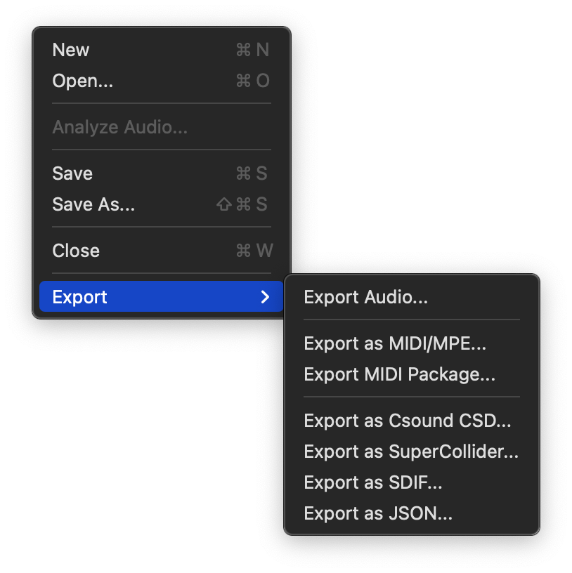

S-06 — File > Export submenu

### 11.1 Export as MIDI/MPE

Exports all partials as a single **MPE** (MIDI Polyphonic Expression) MIDI file, with one note per partial.

Each partial becomes a note with: - **Pitch bend** updated frame-by-frame to track the partial’s frequency - **CC11 (Expression)** updated frame-by-frame to track amplitude - **Note-on velocity** derived from the initial amplitude

Before the file is saved, a dialog asks you to choose a **pitch bend range** (±2, ±12, ±24, or ±48 semitones). The dialog shows the percentage of partials that fit within each range, helping you choose the minimum range that covers your material without sacrificing resolution.

> **Tip:** Use ±12 semitones for lightly pitched material; ±48 for highly chromatic or atonal content.

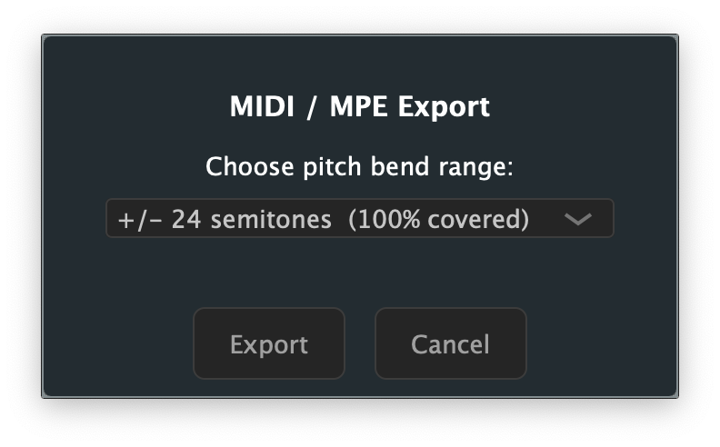

S-44 — MIDI/MPE export dialog showing bend range options

### 11.2 Export MIDI Package

Exports **one MIDI file per partial**, plus a Bill of Materials (BOM) CSV and a readme, all into a folder you choose.

The BOM CSV contains one row per partial with columns: filename, start time, end time, duration, frequency range, amplitude range (dB), peak velocity, bend range used, maximum pitch deviation (cents), and total energy. This data is useful for routing partials to specific instruments or voices in a DAW.

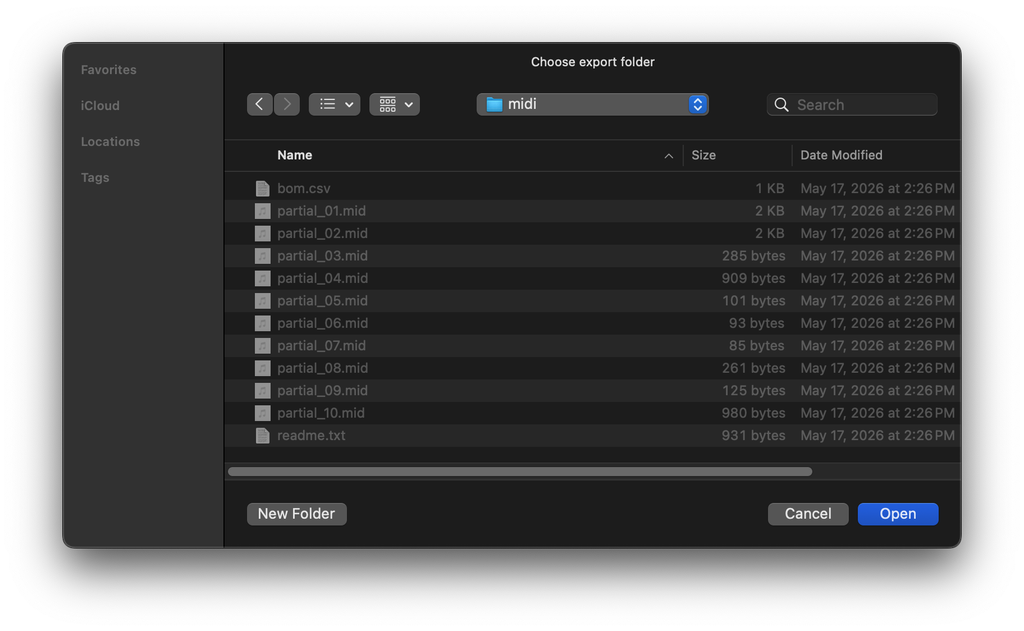

S-45 — MIDI Package folder picker

### 11.3 Export as Csound CSD

Exports a self-contained **Csound CSD** file that exactly reproduces the resynthesis when run with Csound.

The generated file uses one pair of GEN07 function tables per partial (frequency envelope + amplitude envelope), read with a `BufRd`-equivalent instrument. Tempo and sample rate match PartialFKR’s settings (default 48 kHz, 5 ms control period).

**To use**: Open the `.csd` in the Csound IDE or run from the terminal: `csound output.csd`

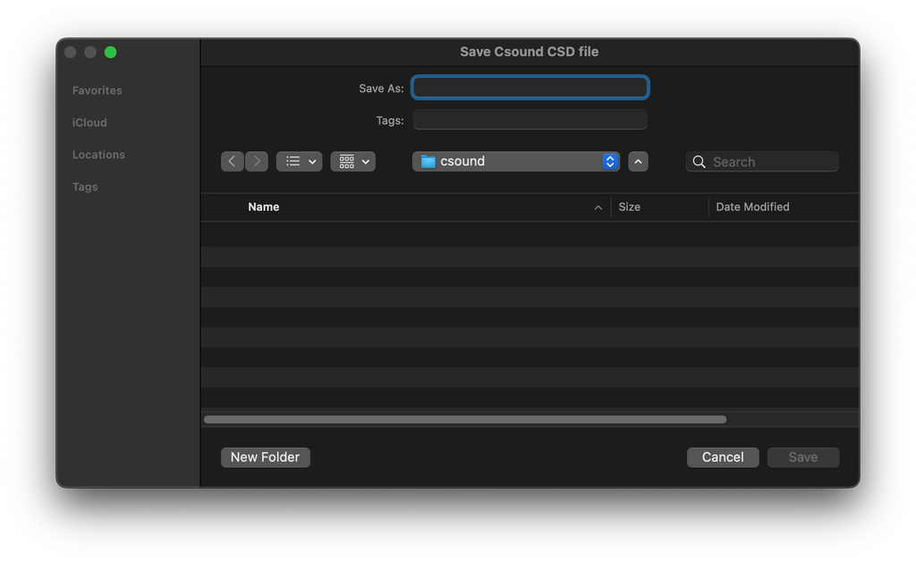

S-47 — Csound CSD export dialog